# Infrastructure Data from BEA

Appears to relate to infrastructure in the US and investment from public and private sector into this.

Data is available from Tidy Tuesday site as well as direct from BEA as an excel spreadsheet.

I will use pre-prepared data but also practice downloading xslx file and then reading this and tidying it using R.

https://github.com/rfordatascience/tidytuesday/tree/master/data/2021/2021-08-10

```r
knitr::opts_chunk$set()
library(tidyverse)
library(readxl)
library(here)
library(skimr)
```

# Tidying Raw Data

Copied from tidy tuesday site - to go through line by line and comment on the code to understand what processes performed.

```r
raw_df  <- readxl::read_excel("2021_08_10_Infrastructure/infrastructure-data-may-2020.xlsx", sheet = 2, skip = 2)
```

```
* `` -> ...1
* `` -> ...2
```

> Q: How do I find out how many sheets are present in an .xlsx file?

```r
gross_inv <- raw_df %>%
  # 1st 2 columns not named so readxl gave them names ...1 &...2
  # use rename function to give them syntactic and appropriate names
  rename(group = ...1, category = ...2) %>%
  # appears to be 1 value missing in each category.
  # these all relate to 1 observation that has no data (r106 blank row in sheet)
  # filter data to remove this row
  filter(!is.na(category)) %>%
  # different 'levels' of category are all entered in one column
  # create a new column that shows the meta_cat i.e. a 'higher level' category
  # these meta-categories are all in rows that have a value in the group column
  # hence '!is.na(group) in ifelse function
  # if not NA then value in 'category' used. if NA then 'NA_character' entered
  mutate(
    meta_cat = if_else(!is.na(group), category, NA_character_),
    group_num = group,
  # by default appear at right end on datsframe
  # '.after' function controls where they are placed
    .after = "category"
    ) %>%
  # some columns contain NA values
  # 'fill' function will replace NAs with the appropriate value
  fill(meta_cat, group_num) %>%
  # data not tidy as there are multiple date columns
  # these should be a single variable
  # use 'pivot_longer' to re-shape the data
  # years converted to character so use 'name_transform' used to convert integers
  pivot_longer(names_to = "year", values_to = "gross_inv", cols = `1947`:`2017`,
               names_transform = list(year = as.integer)
               ) %>%
  # data is duplicated. Rows that have group value still can be filtered out
  # this is why 'group_num' variable created and values added using 'fill'
  # so that original column of 'group' can be used to filter the data
  filter(is.na(group)) %>%
  select(-group)
```

```r
gross_inv %>% write_csv("2021_08_10_Infrastructure/investment.csv")
rm(gross_inv, raw_df)
```

```r
tuesdata <- tidytuesdayR::tt_load('2021-08-10')
```

```
--- Compiling #TidyTuesday Information for 2021-08-10 ----
--- There are 3 files available ---
--- Starting Download ---
```

```
--- Download complete ---
```

```r
ipd <- tuesdata$ipd
chain_investment <- tuesdata$chain_investment
investment <- tuesdata$investment
```

## Exploration

Get to know each of the datasets. Data dictionaries available on github page.

## investment

```r
glimpse(investment)
```

```
Rows: 6,106
Columns: 5
$ category  <chr> "Total basic infrastructure", "Total basic infrastruct~
$ meta_cat  <chr> "Total infrastructure", "Total infrastructure", "Total~
$ group_num <dbl> 1, 1, 1, 1, 1, 1, 1, 1, 1, 1, 1, 1, 1, 1, 1, 1, 1, 1, ~
$ year      <dbl> 1947, 1948, 1949, 1950, 1951, 1952, 1953, 1954, 1955, ~
$ gross_inv <dbl> 4974.662, 6486.770, 7376.143, 7943.959, 8961.233, 9707~
```

```r
skim(investment)
```

```
-- Data Summary ------------------------
                           Values
Name                       investment
Number of rows             6106
Number of columns          5
_______________________
Column type frequency:
  character                2
  numeric                  3
________________________
Group variables            None

-- Variable type: character ----------------------------------------------
# A tibble: 2 x 8
  skim_variable n_missing complete_rate   min   max empty n_unique
* <chr>             <int>         <dbl> <int> <int> <int>    <int>
1 category              0             1     3    64     0       60
2 meta_cat              0             1     5    32     0       16
  whitespace
*      <int>
1          0
2          0

-- Variable type: numeric ------------------------------------------------
# A tibble: 3 x 11
  skim_variable n_missing complete_rate    mean       sd    p0   p25
* <chr>             <int>         <dbl>   <dbl>    <dbl> <dbl> <dbl>
1 group_num             0             1    12.3     6.11     1    8
2 year                  0             1  1982      20.5   1947 1964
3 gross_inv             0             1 13418.  36854.    -194  221.
     p50   p75   p100 hist
*  <dbl> <dbl>  <dbl> <chr>
1   12.5   18      22 ▆▅▅▆▇
2 1982   2000    2017 ▇▇▇▇▇
3 1301.  7986. 500900 ▇▁▁▁▁
```

```r
meta_cat_plot <- function(df, cat){
  df %>%
  filter(meta_cat == cat) %>%
  ggplot()+
  geom_line(aes(x = year, y = gross_inv, colour = category))+
  labs(title = cat)
}
cat <- investment$meta_cat %>% unique
```

```r
categories <- investment$category %>% unique
categories
```

```
 [1] "Total basic infrastructure"
 [2] "Total social infrastructure"
 [3] "Total digital infrastructure"
 [4] "Private"
 [5] "Federal"
 [6] "S&L"
 [7] "Water"
 [8] "Sewer"
 [9] "Conservation and development"
[10] "Power"
[11] "Transportation"
[12] "S&L electric power structures"
[13] "Federal electric power structures"
[14] "Private turbines/steam engines"
[15] "Private wind and solar power structures"
```

[output cut: 45 more lines]

```r
meta_categories <- investment$meta_cat %>% unique
funding <- c("Federal", "Private", "S&L")

meta_categories
```

```
 [1] "Total infrastructure"             "Total basic infrastructure"
 [3] "Water supply"                     "Sewer and waste"
 [5] "Conservation and development"     "Power"
 [7] "Electric power"                   "Natural gas /petroleum power"
 [9] "Transportation"                   "Highways and streets"
[11] "Air /water /other transportation" "Social"
[13] "Health"                           "Education"
[15] "Public safety"                    "Digital"
```

```r
investment %>%
  filter(meta_cat == "Total infrastructure" &
           !category %in% funding) %>%
  ggplot()+
  geom_line(aes(year, gross_inv, colour = category))+
  labs(title = "Total infrastructure")
```

[output not shown]

Most investment is in basic infrastructure which includes conservation & development, power, sewers, transportation and water.

Social infrastructure is the next highest area of investment and this includes education, health and public safety.

The lowest investment is in digital infrastructure. The data includes office buildings, private communications equipment & structures, private computers and private software.

Increases in social infrastructure investment appeared to be increasing exponentially until around 2008 when there was a drop of investment into infrastructure. Basic infrastructure investment seems to be increasing exponentially as does digital despite a considerable drop around 2000.

```r
investment %>%
  group_by(group_num) %>%
  filter(meta_cat == "Total infrastructure" &
           category %in% funding) %>%
  ggplot()+
  geom_line(aes(year, gross_inv, colour = category))+
  labs(title = "Total Infrastructure")
```

[output not shown]

There appears to be more private investment into US infrastructure and this continues to increase despite a slow down in state and local government investment. This private investment appears to be volatile with a couple of dips noted following periods of higher investment (2000, 2008). State and local government investment into infrastructure fell after 2008.

Federal investment into infrastructure is very low.

```r
investment %>%
  filter(meta_cat == "Total basic infrastructure" &
           !category %in% funding) %>%
  ggplot()+
  geom_line(aes(x = year, y = gross_inv, colour = category))+
  labs(title = "Total basic infrastructure")
```

[output not shown]

```r
investment %>%
  filter(meta_cat == "Total basic infrastructure" &
           category %in% funding) %>%
  ggplot()+
  geom_line(aes(x = year, y = gross_inv, colour = category))+
  labs(title = "Total basic infrastructure")
```

[output not shown]

```r
investment %>%
  filter(meta_cat == "Water supply") %>%
  ggplot()+
  geom_line(aes(x = year, y = gross_inv, colour = category))+
  labs(title = "Water supply")
```

[output not shown]

Most investment into water infrastructure is state and local government and this increases each year although has decreased since 2008/2009. Private investment is low and there is no federal investment.

```r
investment %>%
  filter(meta_cat == "Sewer and waste") %>%
  ggplot()+
  geom_line(aes(x = year, y = gross_inv, colour = category))+
  labs(title = "Sewer and waste")
```

[output not shown]

Consider combine water and sewer - looks similar pattern of investment. Plot both together to compare

```r
investment %>%
  filter(meta_cat == "Conservation and development") %>%
  ggplot()+
  geom_line(aes(x = year, y = gross_inv, colour = category))+
  labs(title = "Conservation and development")
```

[output not shown]

Gross investment lower in conservation and development hence large amount of variability year on year.

```r
investment %>%
  filter(meta_cat == "Power") %>%
  ggplot()+
  geom_line(aes(x = year, y = gross_inv, colour = category))+
  labs(title = "Power")
```

[output not shown]

Investment in power infrastructure is predominantly private and increasing exponentially with some year to year variation. Investment fell after peaks in 2000 and 2008 but has now recovered and continued with exponential growth.

```r
investment %>%
  filter(meta_cat == "Electric power") %>%
  ggplot()+
  geom_line(aes(x = year, y = gross_inv, colour = category))+
  labs(title = "Electric power")
```

[output not shown]

```r
investment %>%
  filter(meta_cat == "Natural gas /petroleum power") %>%
  ggplot()+
  geom_line(aes(x = year, y = gross_inv, colour = category))+
  labs(title = "Natural gas /petroleum power")
```

[output not shown]

```r
investment %>%
  filter(meta_cat == "Transportation" &
           category %in% c(funding, "Other private", "Other federal")) %>%
  ggplot()+
  geom_line(aes(x = year, y = gross_inv, colour = category))+
  labs(title = "Transportation")
```

[output not shown]

Investment into transport infrastructure is predominantly from state and local government. Growth has been consistent with an increase in private investment over recent years although this is increasing at a slow rate.

```r
investment %>%
  filter(meta_cat == "Transportation" &
           !category %in% c(funding, "Other private", "Other federal")) %>%
  ggplot()+
  geom_line(aes(x = year, y = gross_inv, colour = category))+
  labs(title = "Transportation")
```

[output not shown]

Most of the investment into transportation infrastructure is into highways and streets and this continues to increase year on year. There has been a slower increase in investment into transit infrastructure.

```r
investment %>%
  filter(meta_cat == "Highways and streets") %>%
  ggplot()+
  geom_line(aes(x = year, y = gross_inv, colour = category))+
  labs(title = "Highways and streets")
```

[output not shown]

Most investment into highways and streets infrastructure in by state and local government.

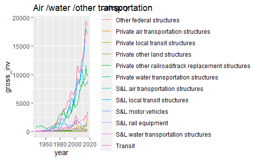

```r
investment %>%
  filter(meta_cat == "Air /water /other transportation") %>%
  ggplot()+
  geom_line(aes(x = year, y = gross_inv, colour = category))+
  labs(title = "Air /water /other transportation")
```

```r
investment %>%
  filter(meta_cat == "Social" &
           !category %in% funding) %>%
  ggplot()+
  geom_line(aes(x = year, y = gross_inv, colour = category))+
  labs(title = "Social infrastructure")
```

[output not shown]

Investment into social infrastructure is predominantly accounted for by education and health. Investment into both increased rapidly from 1990 to 2008 followed by a significant fall. Education investment has only just reached the level achieved before this fall.

```r
investment %>%
  filter(meta_cat == "Social" &
           category %in% funding) %>%
  ggplot()+
  geom_line(aes(x = year, y = gross_inv, colour = category))+
  labs(title = "Social infrastructure")
```

[output not shown]

Social infrastructure investment is predominantly private or from state and local government. It has been increasing since 1980 with a dip in 2008. The pattern is similar to the education/health plot.

```r
investment %>%
  filter(meta_cat == "Education") %>%
  ggplot()+
  geom_line(aes(x = year, y = gross_inv, colour = category))+
  labs(title = "Education")
```

[output not shown]

```r
investment %>%
  filter(meta_cat == "Health") %>%
  ggplot()+
  geom_line(aes(x = year, y = gross_inv, colour = category))+
  labs(title = "Health")
```

[output not shown]

```r
investment %>%
  filter(meta_cat == "Public safety") %>%
  ggplot()+
  geom_line(aes(x = year, y = gross_inv, colour = category))+
  labs(title = "Public safety")
```

[output not shown]

```r
investment %>%
  filter(meta_cat == "Digital") %>%
  ggplot()+
  geom_line(aes(x = year, y = gross_inv, colour = category))+
  labs(title = "Digital infrastructure")
```

[output not shown]

## chain_investment

```r
chain_investment %>%
  filter(meta_cat == "Total infrastructure" &
           !category %in% funding) %>%
  ggplot()+
  geom_line(aes(year, gross_inv_chain, colour = category))+
  labs(title = "Total infrastructure")
```

[output not shown]

```r
chain_investment %>%
  group_by(group_num) %>%
  filter(meta_cat == "Total infrastructure" &
           !category %in% funding) %>%
  mutate(category = fct_rev(category)) %>%
  ggplot()+
  geom_area(aes(year, gross_inv_chain, fill = category), position = "stack")+
  labs(title = "Total Infrastructure")
```

[output not shown]

Investment in all areas has increased in real terms but investment into basic infrastructure has fallen as a proportion of total while social remains steady. There has been a real terms increase in digital infrastructure investment.

```r
chain_investment %>%
  group_by(group_num) %>%
  filter(meta_cat == "Total infrastructure" &
           category %in% funding) %>%
  ggplot()+
  geom_line(aes(year, gross_inv_chain, colour = category))+
  labs(title = "Total Infrastructure")
```

[output not shown]

```r
chain_investment %>%
  group_by(group_num) %>%
  filter(meta_cat == "Total infrastructure" &
           category %in% funding) %>%
  mutate(category = fct_rev(category)) %>%
  ggplot()+
  geom_area(aes(year, gross_inv_chain, fill = category), position = "stack")+
  labs(title = "Total Infrastructure")
```

[output not shown]

The proportion of private investment into infrastructure has increase as federal investment decreases and state & local government funding remains fairly constant

```r
chain_investment %>%
  filter(meta_cat == "Total basic infrastructure" &
           !category %in% funding) %>%
  ggplot()+
  geom_line(aes(x = year, y = gross_inv_chain, colour = category))+
  labs(title = "Total basic infrastructure")
```

[output not shown]

Transportation and power infrastructure investment show the biggest increases in real terms over time.

```r
chain_investment %>%
  filter(meta_cat == "Power") %>%
  ggplot()+
  geom_line(aes(x = year, y = gross_inv_chain, colour = category))+
  labs(title = "Power")
```

[output not shown]

Most investment into power is private.

```r
chain_investment %>%
  filter(meta_cat == "Electric power") %>%
  ggplot()+
  geom_line(aes(x = year, y = gross_inv_chain, colour = category))+
  labs(title = "Electric power")
```

[output not shown]

Most investment into power has been private with a noticeable increase in wind and solar since 2004.

```r
chain_investment %>%
  filter(meta_cat == "Electric power") %>%
  ggplot()+
  geom_area(aes(x = year, y = gross_inv_chain, fill = category), position = "fill")+
  labs(title = "Electric power")
```

[output not shown]

No federal investment and proportion S&L investment falling in real terms. Although wind and solar are increasing they still represent a small proportion of overall investment into electrical power infrastructure.

```r
chain_investment %>%
  filter(meta_cat == "Transportation" &
           category %in% c(funding, "Other private", "Other federal")) %>%
  ggplot()+
  geom_line(aes(x = year, y = gross_inv_chain, colour = category))+
  labs(title = "Transportation")
```

[output not shown]

Investment into transportation infrastructure is predominantly S&L with a general upward trajectory in real terms although there are some peaks and troughs evident.

```r
chain_investment %>%
  filter(meta_cat == "Transportation" &
           !category %in% c(funding, "Other private", "Other federal")) %>%
  ggplot()+
  geom_line(aes(x = year, y = gross_inv_chain, colour = category))+
  labs(title = "Transportation")
```

[output not shown]

Most investment is in highways and streets and the pattern is similar to the pattern of investment into transport infrastructure by S&L.

```r
chain_investment %>%
  filter(meta_cat == "Social" &
           !category %in% funding) %>%
  ggplot()+
  geom_line(aes(x = year, y = gross_inv_chain, colour = category))+
  labs(title = "Social infrastructure")
```

[output not shown]

Education and health infrastructure investment make up the majority of investment into social infrastructure. Health investment continues to increase in real terms while education infrastructure investment is more variable with significant dips - possibly at times of recession.

```r
chain_investment %>%
  filter(meta_cat == "Education") %>%
  ggplot()+
  geom_line(aes(x = year, y = gross_inv_chain, colour = category))+
  labs(title = "Education")
```

[output not shown]

The largest investment is S&L investment into K-12 education. This demonstrates the same pattern as the trends in education investment. In real terms current investment is only just above the peak in the late 1960s. Would be interesting to include population with this data to see what spending per capita is.

```r
chain_investment %>%
  filter(meta_cat == "Health") %>%
  ggplot()+
  geom_line(aes(x = year, y = gross_inv_chain, colour = category))+
  labs(title = "Health")
```

[output not shown]

Real terms infrastructure investment has increase rapidly despite recessions and appears to be mainly accounted for by investment into medical equipment by the private sector. Investment into hospitals appears to be relatively static.

## Questions for further exploration